# 15 Minute Cities in the Urban-Rural Nexus

This tutorial shows one way to compute and map the 15 minute city with R, focusing on Urban Rural differences.

**Access to Services based on Euclidean Distance**

As a first step, services that can be accessed in 10 minute walk need to be identified. To do so, we will use a metric based on Euclidean distance, selecting POIs which fall within a 800 meters radius from each postcode in the Lothian region.

```r
library(tidyverse) # this library will be used for all data wrangling instructions
library(sf) # this is a well-established library to deal with spatial data
#library(nngeo) #this library will be used to compute distances

#DO NOT RUN

# #load the data and pre-process
#
# origins<-st_read("data/postcodes.gpkg") %>% #UK data have a specific Coordinate Reference System (British National Grid)
#   st_transform(4326) #globally WGS84 is generally used. Here, we therefore transform the CRS to WGS84
#
# origins <- origins %>% #create a unique ID for the origins
#   mutate(
#     id=as.numeric(rownames(origins))
#   )
#
# destinations<-st_read("data/POIs.gpkg")
#
# destinations<- destinations %>% #create a unique ID for the destinations
#   mutate(
#     id=as.numeric(rownames(destinations))
#   )
#
# #Compute distances from each origin and select POIs within 800 meters
#
# #nn_out <- st_nn(origins, destinations, k=50, maxdist = 800)
#
# #The steps above take too much time and are heavy, for the purpose of this tutorial you will directly load the results. You will have access to the fully reproducible repository that you can re-use with your machine
# nn_out <- readRDS("data/nn_out.RDS")
#
# #post-processing
# #transform results from list to dataframe
# results <- data.frame(
#               id = rep(
#               seq_along(nn_out),
#               lengths(nn_out)
#               ),
#               dest = unlist(nn_out)
#             ) %>%
#           inner_join(st_drop_geometry(origins), by = c("id" = "id"))%>%
#           inner_join(st_drop_geometry(destinations), by = c("dest" = "id")) %>%
#   select(id,DataZone,fclass)
#
# saveRDS(results, "data/results.RDS")

results <- readRDS("data/results.RDS")

head(results)
```

|  | id | DataZone | fclass |
| --- | --- | --- | --- |
| 1 | 1 | S01008674 | bar |
| 2 | 1 | S01008674 | hotel |
| 3 | 1 | S01008674 | bank |
| 4 | 1 | S01008674 | camera_surveillance |
| 5 | 1 | S01008674 | atm |
| 6 | 1 | S01008674 | atm |

```r
NA
```

```r
#compute the average number of poi accessible in 10-min walk in each data zone and the average number of services type

results_processed <- results %>%
  group_by(DataZone) %>%
  summarise(
    poi = n(),
    service=length(unique(fclass)),
    pc = length(unique(id)),
    poiAvg = poi/pc
    )

head(results_processed)
```

| DataZone | poi | service | pc | poiAvg |
| --- | --- | --- | --- | --- |
| S01008163 | 225 | 6 | 21 | 10.714286 |
| S01008164 | 334 | 11 | 31 | 10.774194 |
| S01008165 | 379 | 16 | 41 | 9.243902 |
| S01008166 | 147 | 6 | 15 | 9.800000 |
| S01008167 | 203 | 6 | 19 | 10.684211 |
| S01008168 | 320 | 11 | 21 | 15.238095 |

```r
NA
```

**Mapping the Results**

We can now visualise the results on a map to reflect on the spatial distribution of services.

```r
library(ggplot2)

#load spatial boundaries and join them with the results obtained in the previous section
#let's start with the number of different service by data zone
dataZones<-st_read("data/dataZones_UR.gpkg") %>%
  inner_join(results_processed, by=c("DataZone"="DataZone"))
colnames(dataZones)
```

```
 [1] "DataZone"   "Name"       "TotPop2011" "ResPop2011"
 [5] "HHCnt2011"  "StdAreaHa"  "StdAreaKm2" "Shape_Leng"
 [9] "Shape_Area" "URValue"    "poi"        "service"
[13] "pc"         "poiAvg"     "geom"
```

Map showing the average number of POIs accessible in 10 minute walk per resident (pp)

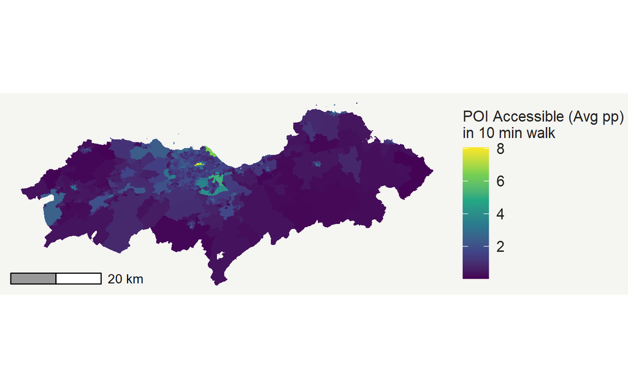

```r
ggplot()+
  geom_sf(aes(fill = poiAvg/(ResPop2011/pc)),
          colour = "NA",
          data = dataZones) +
  #change color palette
  scale_fill_viridis_c() +
  #change the background
  theme_void() +
  #add a scale bar
  ggspatial::annotation_scale(
    location = "bl",
    bar_cols = c("grey60", "white")
    ) +
  #change legend title
  labs(fill = "POI Accessible (Avg pp) \nin 10 min walk")+
  #customize theme
  theme(
    text = element_text(family = "Futura-Medium",color = "#22211d"),
    legend.title = element_text(family = "Futura-Bold", size = 10),
    legend.text = element_text(family = "Futura-Medium", size = 10),
    plot.background = element_rect(fill = "#f5f5f2", color = NA),
    panel.background = element_rect(fill = "#f5f5f2", color = NA)
    )
```

Map showing the average services’ types accessible in 10 minute walk

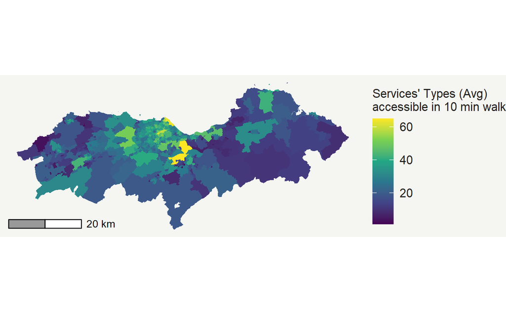

```r
ggplot()+
  geom_sf(aes(fill = service),
          colour = "NA",
          data = dataZones) +
  #change color palette
  scale_fill_viridis_c() +
  #change the background
  theme_void() +
  #add a scale bar
  ggspatial::annotation_scale(
    location = "bl",
    bar_cols = c("grey60", "white")
    ) +
  #change legend title
  labs(fill = "Services' Types (Avg)\naccessible in 10 min walk")+
  #customize theme
  theme(
    text = element_text(family = "Futura-Medium",color = "#22211d"),
    legend.title = element_text(family = "Futura-Bold", size = 10),
    legend.text = element_text(family = "Futura-Medium", size = 10),
    plot.background = element_rect(fill = "#f5f5f2", color = NA),
    panel.background = element_rect(fill = "#f5f5f2", color = NA)
    )
```

Create and map a score which accounts for both POIs per person and service’s types

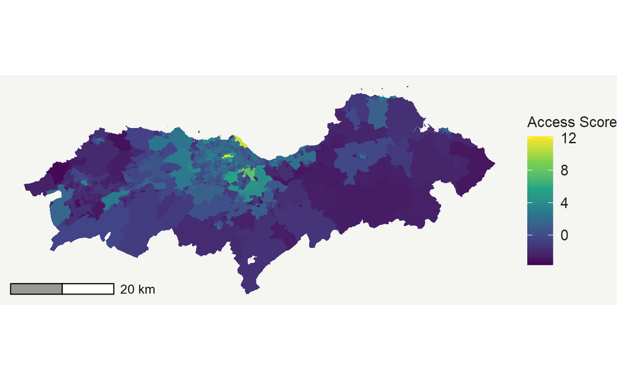

```r
dataZones<-dataZones %>%
  mutate(
    score = scale(poiAvg/(ResPop2011/pc)) + scale(service)
    )

#map the score

ggplot()+
  geom_sf(aes(fill = score),
          colour = "NA",
          data = dataZones) +
  #change color palette
  scale_fill_viridis_c() +
  #change the background
  theme_void() +
  #add a scale bar
  ggspatial::annotation_scale(
    location = "bl",
    bar_cols = c("grey60", "white")
    ) +
  #change legend title
  labs(fill = "Access Score")+
  #customize theme
  theme(
    text = element_text(family = "Futura-Medium",color = "#22211d"),
    legend.title = element_text(family = "Futura-Bold", size = 10),
    legend.text = element_text(family = "Futura-Medium", size = 10),
    plot.background = element_rect(fill = "#f5f5f2", color = NA),
    panel.background = element_rect(fill = "#f5f5f2", color = NA)
    )
```

**The Rural-Urban nexus**

Let’s now look at the access to services gaps between urban and rural areas.

The Scottish Urban-Rural classification distinguishes between:

1. Large Urban Areas Settlements of 125,000 people and over.
2. Other Urban Areas Settlements of 10,000 to 124,999 people.
3. Accessible Small Towns Settlements of 3,000 to 9,999 people, and within a 30 minute drive time of a Settlement of 10,000 or more.
4. Remote Small Towns Settlements of 3,000 to 9,999 people, and with a drive time of over 30 minutes to a Settlement of 10,000 or more.
5. Accessible Rural Areas Areas with a population of less than 3,000 people, and within a 30 minute drive time of a Settlement of 10,000 or more.
6. Remote Rural Areas Areas with a population of less than 3,000 people, and with a drive time of over 30 minutes to a Settlement of 10,000 or more.

```r
head(dataZones)
```

```
Simple feature collection with 6 features and 15 fields
Geometry type: MULTIPOLYGON
Dimension:     XY
Bounding box:  xmin: 304051 ymin: 666284 xmax: 306584 ymax: 668123
Projected CRS: OSGB36 / British National Grid
   DataZone               Name TotPop2011 ResPop2011 HHCnt2011
1 S01013282 Dedridge East - 06        827        827       346
2 S01013283 Dedridge East - 07        642        642       310
3 S01013309        Howden - 01        636        618       236
4 S01013311        Howden - 03        804        801       313
5 S01013310        Howden - 02        649        649       241
6 S01013314        Howden - 06        670        670       304
  StdAreaHa StdAreaKm2 Shape_Leng Shape_Area URValue  poi
1 22.927535   0.229276   2289.196  229275.35       2  437
2 71.323802   0.713238   5861.973  713238.02       2 1650
3 79.666304   0.796663   7235.210  796663.03       2  859
4 21.167156   0.211672   2022.750  211671.56       2  448
5  9.516558   0.095166   1449.068   95165.58       2  300
6 40.736800   0.407369   3389.856  407368.00       2  531
  service pc   poiAvg                           geom      score
1      23  9 48.55556 MULTIPOLYGON (((306283 6664... -0.9496032
2      40 33 50.00000 MULTIPOLYGON (((306271.3 66...  3.4159445
3      35 21 40.90476 MULTIPOLYGON (((305581.3 66...  1.3346866
4      30  9 49.77778 MULTIPOLYGON (((306085.1 66... -0.2658971
5      26  6 50.00000 MULTIPOLYGON (((305829 6671... -0.7658032
6      24 13 40.84615 MULTIPOLYGON (((305665 6677... -0.4947058
```

URValue corresponds to the classes above. Let’s create more legible classes.

```r
dataZones <- dataZones %>%
  mutate(
    URclasses = case_when(
      URValue == 1 ~ "Large Urban Areas",
      URValue == 2 ~ "Other Urban Areas",
      URValue == 3 ~ "Small Towns",
      URValue == 5 ~ "Accessible Rural Areas"
    ),
    URclasses = factor(URclasses, levels = c("Large Urban Areas", "Other Urban Areas", "Small Towns", "Accessible Rural Areas"))
  )
```

Map of Urban and Rural Areas in the Lothian region.

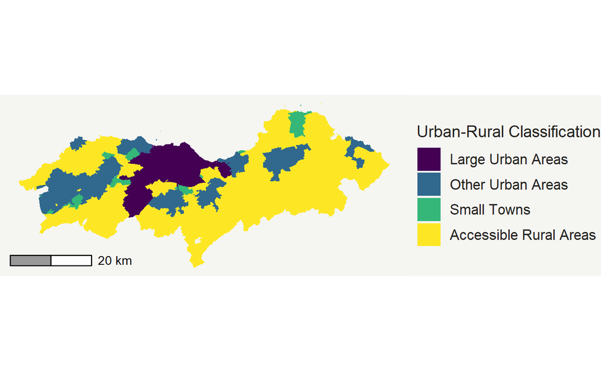

```r
ggplot()+
  geom_sf(aes(fill = URclasses),
          colour = "NA",
          data = dataZones) +
  #change color palette
  scale_fill_viridis_d() +
  #change the background
  theme_void() +
  #add a scale bar
  ggspatial::annotation_scale(
    location = "bl",
    bar_cols = c("grey60", "white")
    ) +
  #change legend title
  labs(fill = "Urban-Rural Classification")+
  #customize theme
  theme(
    text = element_text(family = "Futura-Medium",color = "#22211d"),
    legend.text = element_text(family = "Futura-Medium", size = 10),
    plot.background = element_rect(fill = "#f5f5f2", color = NA),
    panel.background = element_rect(fill = "#f5f5f2", color = NA)
    )
```

Bar Plot of the Urban-Rural Gap

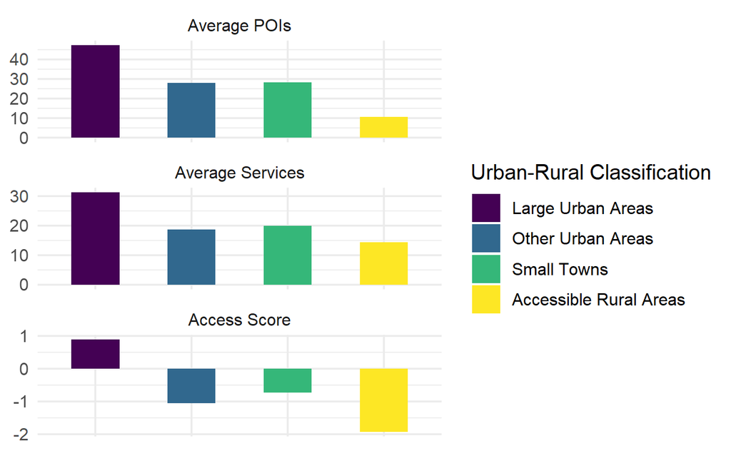

```r
dataZones %>%
  st_drop_geometry() %>%
  group_by(URclasses) %>%
  summarise(
    c_poiAvg = mean(poiAvg, rm.na = TRUE),
    c_service = mean(service, rm.na = TRUE),
    c_score = mean(score, rm.na = TRUE)
  ) %>%
  pivot_longer(cols = starts_with("c_"), names_to = "variable", values_to = "value")%>%
  mutate(
    variable = factor(variable, levels = c("c_poiAvg","c_service","c_score"), labels = c("Average POIs", "Average Services", "Access Score"))
  ) %>%
  ggplot(aes(x = URclasses, y = value, fill = URclasses))+
  geom_bar(stat = "identity", width = 0.5) +
  scale_fill_viridis_d() +
  facet_wrap(~variable, scales = "free", ncol = 1) +
  labs(fill = "Urban-Rural Classification") +
  theme_minimal()+
  theme(axis.title = element_blank(), axis.text.x = element_blank(), text = element_text(size = 12))
```